# Red Wine Exploration by Prabhpreet Sandhu

```
## 'data.frame':    1599 obs. of  13 variables:
##  $ X                   : int  1 2 3 4 5 6 7 8 9 10 ...
##  $ fixed.acidity       : num  7.4 7.8 7.8 11.2 7.4 7.4 7.9 7.3 7.8 7.5 ...
##  $ volatile.acidity    : num  0.7 0.88 0.76 0.28 0.7 0.66 0.6 0.65 0.58 0.5 ...
##  $ citric.acid         : num  0 0 0.04 0.56 0 0 0.06 0 0.02 0.36 ...
##  $ residual.sugar      : num  1.9 2.6 2.3 1.9 1.9 1.8 1.6 1.2 2 6.1 ...
##  $ chlorides           : num  0.076 0.098 0.092 0.075 0.076 0.075 0.069 0.065 0.073 0.071 ...
##  $ free.sulfur.dioxide : num  11 25 15 17 11 13 15 15 9 17 ...
##  $ total.sulfur.dioxide: num  34 67 54 60 34 40 59 21 18 102 ...
##  $ density             : num  0.998 0.997 0.997 0.998 0.998 ...
##  $ pH                  : num  3.51 3.2 3.26 3.16 3.51 3.51 3.3 3.39 3.36 3.35 ...
##  $ sulphates           : num  0.56 0.68 0.65 0.58 0.56 0.56 0.46 0.47 0.57 0.8 ...
##  $ alcohol             : num  9.4 9.8 9.8 9.8 9.4 9.4 9.4 10 9.5 10.5 ...
##  $ quality             : int  5 5 5 6 5 5 5 7 7 5 ...
```

```
##        X          fixed.acidity   volatile.acidity  citric.acid
##  Min.   :   1.0   Min.   : 4.60   Min.   :0.1200   Min.   :0.000
##  1st Qu.: 400.5   1st Qu.: 7.10   1st Qu.:0.3900   1st Qu.:0.090
##  Median : 800.0   Median : 7.90   Median :0.5200   Median :0.260
##  Mean   : 800.0   Mean   : 8.32   Mean   :0.5278   Mean   :0.271
##  3rd Qu.:1199.5   3rd Qu.: 9.20   3rd Qu.:0.6400   3rd Qu.:0.420
##  Max.   :1599.0   Max.   :15.90   Max.   :1.5800   Max.   :1.000
##  residual.sugar     chlorides       free.sulfur.dioxide
##  Min.   : 0.900   Min.   :0.01200   Min.   : 1.00
##  1st Qu.: 1.900   1st Qu.:0.07000   1st Qu.: 7.00
##  Median : 2.200   Median :0.07900   Median :14.00
##  Mean   : 2.539   Mean   :0.08747   Mean   :15.87
##  3rd Qu.: 2.600   3rd Qu.:0.09000   3rd Qu.:21.00
##  Max.   :15.500   Max.   :0.61100   Max.   :72.00
##  total.sulfur.dioxide    density             pH          sulphates
##  Min.   :  6.00       Min.   :0.9901   Min.   :2.740   Min.   :0.3300
##  1st Qu.: 22.00       1st Qu.:0.9956   1st Qu.:3.210   1st Qu.:0.5500
##  Median : 38.00       Median :0.9968   Median :3.310   Median :0.6200
##  Mean   : 46.47       Mean   :0.9967   Mean   :3.311   Mean   :0.6581
##  3rd Qu.: 62.00       3rd Qu.:0.9978   3rd Qu.:3.400   3rd Qu.:0.7300
##  Max.   :289.00       Max.   :1.0037   Max.   :4.010   Max.   :2.0000
##     alcohol         quality
##  Min.   : 8.40   Min.   :3.000
##  1st Qu.: 9.50   1st Qu.:5.000
##  Median :10.20   Median :6.000
##  Mean   :10.42   Mean   :5.636
##  3rd Qu.:11.10   3rd Qu.:6.000
##  Max.   :14.90   Max.   :8.000
```

Quality is numeric variable. Converting it to factor variable for analysis and adding a new variable to the dataset.

# Univariate Plots Section

Univariate plots to understand which variables are normal or close to normal distribution.

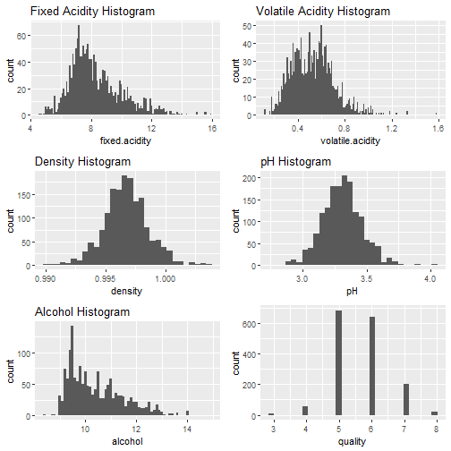

All there variables are normally or close to normal distriburion.

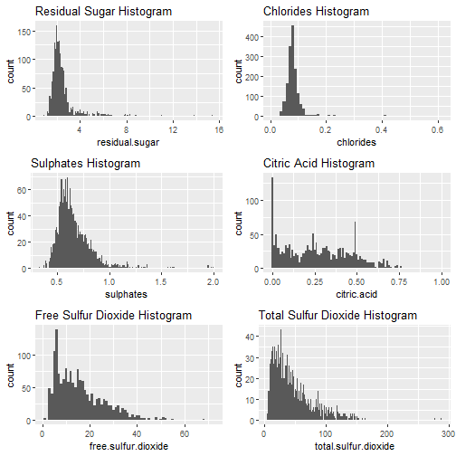

All these variables are not normally distributed.

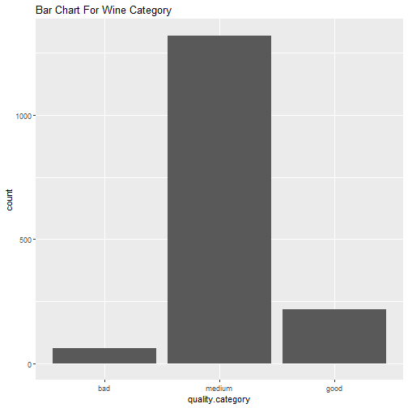

Bar Chart for qulity.category (new column added)

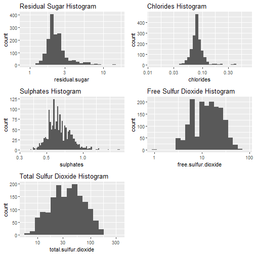

Data Transformations for properties which are not normally distributed

# Univariate Analysis

### What is the structure of your dataset?

There are 1599 observations, and 11 properties of the wine. Then I converted quality variable to factor variable, and added a new column to the dataset. And then added 1 more column quality.category to the dataset. Observations: 1. Most of the red wine quality rating is 5/6. 2. Maximum wine quality dataset belongs to medium after categorising the wine quality. 3. Limited Data for other qualities. 4. Red Wine properties: fixed.acidity, volatile.acidity, density, pH, alcohol are close to normal distribution. 5. Red Wine properties: residual.sugar, chlorides, sulphates, citric.acid, free.sulfur.dioxide, total.sulfur.dioxide are not normally distributed.

### What is/are the main feature(s) of interest in your dataset?

To investigate what properties of the wine affects the rating of the wine.

Features like pH, alcohol, sulphates, chorides will help.

# Bivariate Plots Section

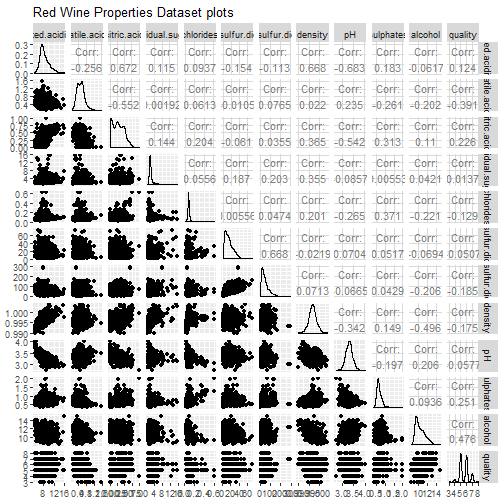

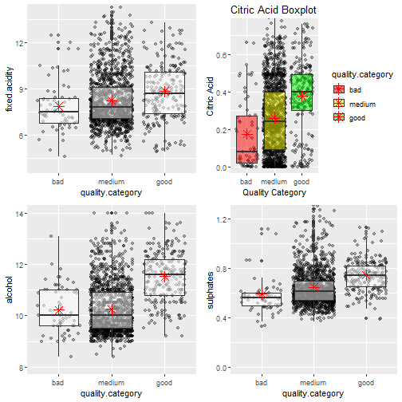

Looking at these box plots, as the quantity increases better the rating of the wine.

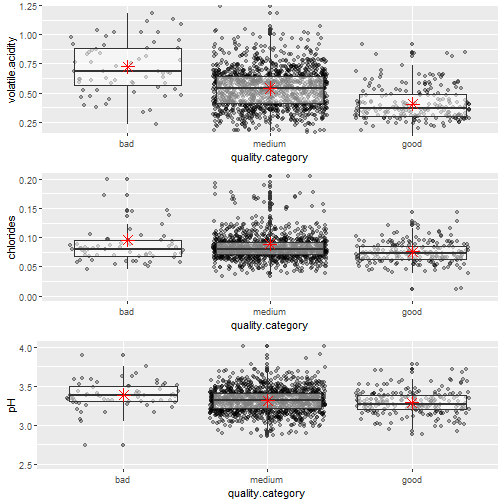

Looking at these Box Plots, we can say that as the quantity decreases, the quality rating gets better for Red wine.

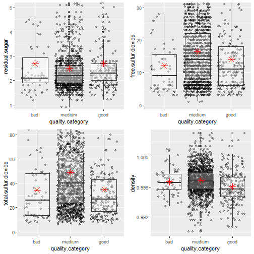

These properties doesn't seem to have any effect on the quality rating of the wine.

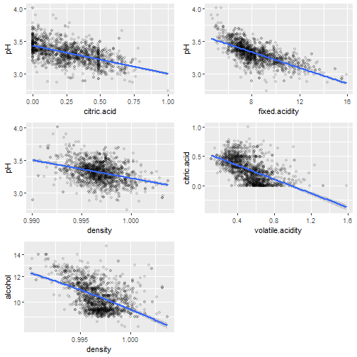

These variables have negative correlations with each other.

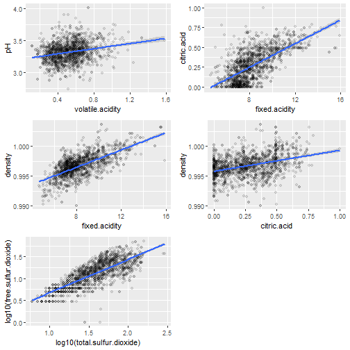

These variable have positive correlation.

# Bivariate Analysis

investigation. How did the feature(s) of interest vary with other features in \ the dataset? Positive corelations among variables 1. fixed.acidity & density 2. fixed.acidity & citric.acid 3. pH & volatile.acidity

Negative correlation 1. pH & fixed.acidity 2. pH & citric.acid 3. pH & density 4. citric.acid & volatile.acidity 5. alcohol & density

(not the main feature(s) of interest)? There's a strong positive correlation between total.sulfur.dioxide & free.sulfur.dioxide.

### What was the strongest relationship you found?

Strongest positive correlation is between 1. fixed.acidity & citric.acid 2. fixed.acidity & density 3. total.sulfur.dioxide & free.sulfur.dioxide

# Multivariate Plots Section

[output not shown]

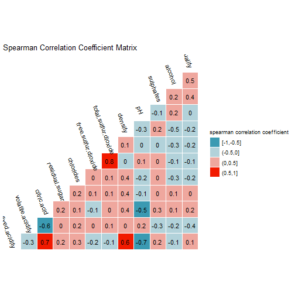

These were the outcome of the boxplot as well. Now let's concentrate on the main 4 chemical properties of red wine, which were outcome of bivariate analysis & correlation matrix.

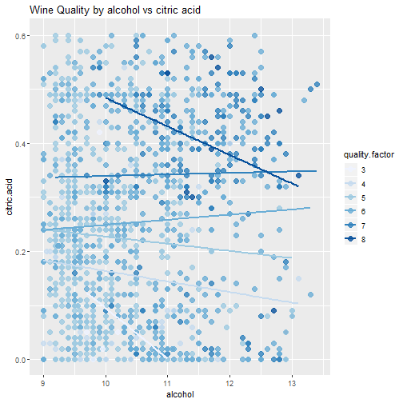

High alcohol & high level of citric.acid produces better quality wines.

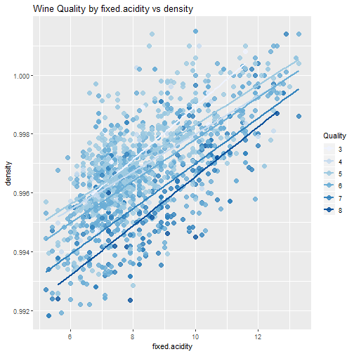

Low Density wines & High fixed.acidity are better wine quality.

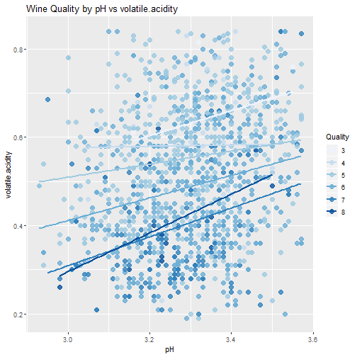

Wines with low volatile.acidity are better quality wines.

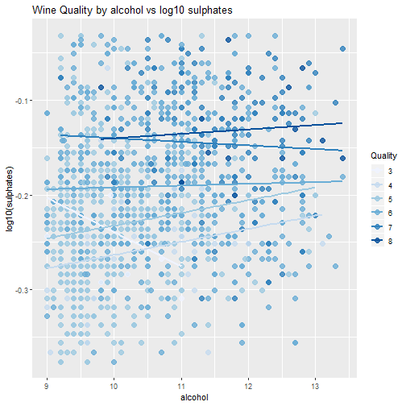

High level of sulphates with higher alcohol are better wines.

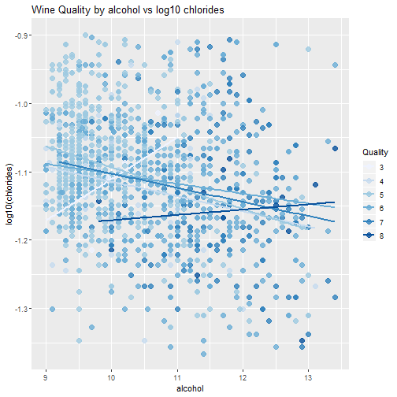

chlorides does not have any effect on the wine quality.

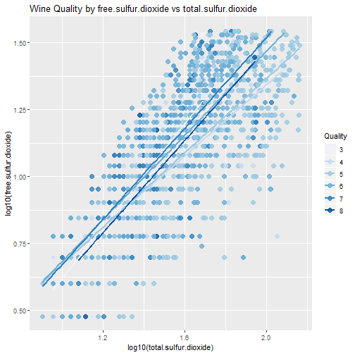

free.sulfur.dioxide does not have any effect on the wine quality.

## Linear model for Quality

In model m1, I add those properties which seem to have positive strong correlation with wine quality. F-statistic comes out to be 159 & R-squared is 0.2862.

Next I add those variables which seem to have negative correlation with wine quality to m1. F-statistic drops to 120 & R-squared improves to 0.345. Here density and pH seems to loose the significance.

Next adding those properties which doesn't seem to have any effect on the wine quality. F-statistic falls significantly to 81 and R-squared improved to 0.3606

But the p-value for all the 3 models doesn't change.

# Multivariate Analysis

investigation. Were there features that strengthened each other in terms of \ looking at your feature(s) of interest?

Wines with High 1. alcohol 2. sulphates 3. fixed.acidity 4. citric.acid are better quality wines.

But 1. free.sulfur.dioxide 2. chlorides does not have any effect on the wine quality.

Low 1. volatile.acidity 2. density gives better rating for wines.

moderate pH seems to produce better wines.

### Were there any interesting or surprising interactions between features?

And decreasing the quantity of chlorides seemed to have better quality wines in boxplots. But multivariate plots depicted that chlorides have no effect on the wine quality.

strengths and limitations of your model.

created 3 linear models for the dataset with 11 datapoints 1. alcohol + fixed.acidity + sulphates + citric.acid 2. alcohol + fixed.acidity + sulphates + citric.acid + volatile.acidity + pH 3. alcohol + fixed.acidity + sulphates + citric.acid + volatile.acidity + pH + residual.sugar + chlorides + free.sulfur.dioxide + total.sulfur.dioxide + density

Since he dataset has majority of the wines in medium group, there's very limited data for bad (1-4) and good (7-10) quality wines, it doesn't seem to predict properly. If we have more data for these quality wines then it would be a better predicting model.

# Final Plots and Summary

### Plot One

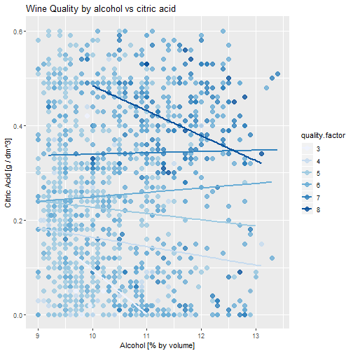

### Description One

This Chart clearly depicts that wines with high citric.acid & high alcohol wines are better wines.

### Plot Two

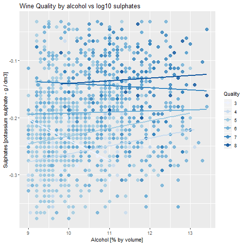

### Description Two

This plot clearly depicts high alcohol levels and high sulphates levels produce better quality wines.

### Plot Three

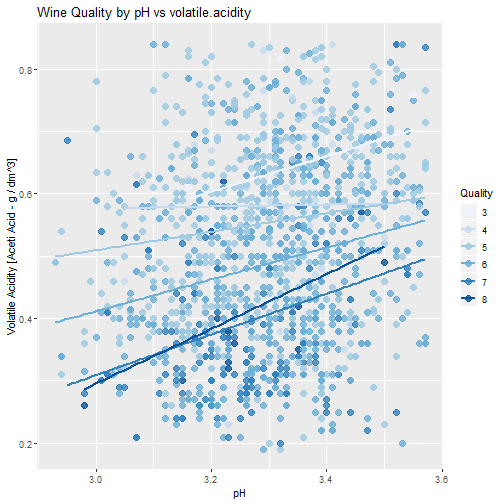

# Reflection

Since the dataset is limited to the majority of the medium quality wines, it was hard to depict what properties would have played important role in determining the quality of the red wine.

When fitted linear model with all the variables, citric.acid and fixed.acidity lost the significance but for other 2 linear models m1 & m2, these are important properties to consider.